# RVH Research

## What is the RVH?

Growing up almost every coach I had wanted me to stand-up ‘more’ - more being a relative term. Most made peace with the fact that I was going to try to make the same type of saves as Dominik Hasek or Patrick Roy but since I was still a kid, it would probably help if stood up once in a while. Still they had to choose their battles wisely, most picked the same hill to die on: bad angle shots. It was simple geometry really, with the right stick position you could stand there and cover 100% of the net. Let me tell you, there’s nothing worse than standing there while people hack away at your feet knowing you can’t cover the puck with your big toe and dropping to your knees with the puck that tight would create a hole anybody could hit.

By time I got to junior and had a goalie coach we worked in the Vertical-Horizontal (VH) to deal with shots from sharp angle. The strong pad would seal the post (vertical) and the back leg would drop sealing the ice (horizontal). There was always a risk of getting your stick tied up and/or getting beat between the post and skate, but used properly it was pretty tough to beat from range, however there were trade-offs. Leading with pad tied up the hands a bit and meant rebounds were more difficult to control. If there was a rebound the VH was configured well to push off the post, but only in one direction. If you had kept your knee tight to the goalline, but need to push to the top of the crease, too bad, you were pushing across the goalline.

The Reverse Vertical Horizontal (RVH) flipped the configuration of the pads, so the strong pad seals the ice (horizontal) and back leg remains anchored (vertical), freeing up the hands and stick more to make plays and allowing rotation with the back leg and push off with the post leg (I would have never dreamed of this, most nets growing up were easy to knock off whenever you needed a conveinent whistle). The back leg can anchor or drop into a butterfly quickly which gives the RVH more flexibility when repeling a play originating from a sharp angle compared to the VH.

This added flexibility has meant RVH has mostly supplanted VH as a tactic for sharp angle shots, but it’s not perfect either since it leaves a few holes along the post above the pad, particularly over the shoulder. Additionally, because of its flexibility some goaltender’s become too reliant on it, defaulting to it prematural or in situations that don’t call for it. After all, throughout the VH and RVH it was always an option to play sharp angle shots more passively standing up (perhaps anticipating a pass or change of angle) or more aggressively by moving off the post and squaring up. The RVH is a great tactic, but it’s up to the goalie to assess the shooter speed, handedness, and passing options and defensive support and making a read rather than simply defaulting to the RVH.

## What does the data say?

As early as 2014, [InGoal Magazine’s Greg Balloch discussed the RVH being over-used situationally and improperly](http://ingoalmag.com/technique/reverse-vh-common-issues-proper-execution/), including at the NHL level. You don’t need to watch too many nights of highlights to see someone who’s 6’5" inexplicitly getting beat over the shoulder from a bad angle shot because they were leaning on the post in the RVH. Is this is a growing problem or just the cost of doing business while the benefits outweigh the negatives?

Looking at NHL play-by-play from 2010-2018, we can isolate shots from the RVH has been presumably been used properly and possibly improperly to see if there are any patterns in the:

- Share of shots resulting in goals (obvious why this matters)
- Number of shots attempted per game (perhaps RVH has encouraged or discouraged bad angle shots)
- Share of shots resulting in rebounds (are some tactics more prone to rebounds than others)
- Shooting % on rebounds, or calculated expected goals on rebounds if sample size is too sample (are some tactic more prone to *bad* rebounds that are more likely to be converted in goals or possibly leave the goalie less likely to make the rebound save)

Observing these metrics over the last 8 seasons might reveal a meaningful change in success rates, but it important to caution that while this appear to be a testable tactic, in a complex game like hockey, effects can be hard to pin down. We don’t have passing data to reveal if, for example, a more aggressive tactic led to more passing from the sharp angle to more dangerous locations, though the number of attempts per game might lend a hint.

Either way it’s possible macro trends don’t reveal anything meaningful since there’s much that unobserved and the data itself is imperfect. The coordinate data has been adjusted to hopefully improve accuracy of shot location.

That said, it is an interesting question, with a potentially meaningful and interesting answer in the data.

First, look at a sample of the data available.

```r
## Load data
load("~/Documents/CWA/Hockey Data/goalie_shot_level_prep.RData")

## Print columns
head(goalie_shot_level_prep)
```

```
##       xG_raw         xR        Away_Coach Away_Goalie Away_Goalie_Id
## 1 0.10140381 0.05456016 WILLIE DESJARDINS RYAN MILLER        8468011
## 2 0.16793406 0.04447408 WILLIE DESJARDINS RYAN MILLER        8468011
## 3 0.02312121 0.02173777 WILLIE DESJARDINS RYAN MILLER        8468011
## 4 0.11102723 0.02010524 WILLIE DESJARDINS RYAN MILLER        8468011
## 5 0.02496245 0.01945708 WILLIE DESJARDINS RYAN MILLER        8468011
## 6 0.01541898 0.01617496 WILLIE DESJARDINS RYAN MILLER        8468011
##   Away_Players Away_Score Away_Team       Date
## 1            6          0       VAN 2016-10-23
## 2            6          0       VAN 2016-10-23
## 3            6          0       VAN 2016-10-23
## 4            6          0       VAN 2016-10-23
## 5            6          0       VAN 2016-10-23
## 6            6          0       VAN 2016-10-23
##                                                                        Description
```

[output cut: 195 more lines]

## What does the data look like?

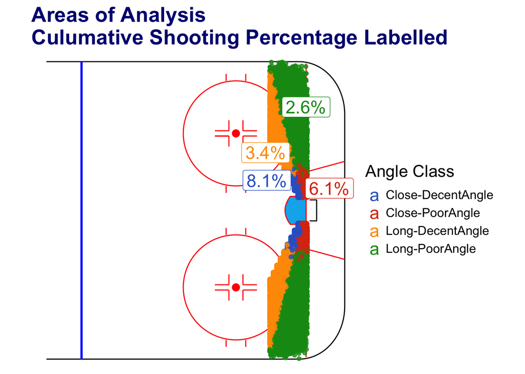

```r
rink <- fun.draw_rink() + coord_fixed()

shot_dist <- 12

## Take all shots and create features
all_nonrush_shots <- goalie_shot_level_prep %>%
      arrange(season, Game_Id, Seconds_Elapsed) %>%
      ## Flag if shot coordinate
      filter(EmptyNet_SA == 0) %>%
      filter(is_Rebound == 0) %>%
      ## Orient all shots on same end of rink
      mutate(xC = ifelse(Direction == 1, xC, -1 * xC),
             yC = ifelse(Direction == 1, yC, -1 * yC),
             Results_inRebound = ifelse(Results_inRebound == 1 & lead(Shot_Distance) <= 30, 1, 0)) %>%
      ## Limit variables
      select(xC, yC, is_Rebound, Results_inRebound, xR, Goal, SA_Goalie, Player_Position2, p1_name, season, Game_Id, Seconds_Elapsed, lagged_Event, Type, Strength, xG, Shooter_Handedness, Handed_Class, Game_State, Shot_Distance) %>%
      ## Create variables
      mutate(bad_angle = ifelse(((abs(yC) > 3) & (xC <= 89) & (xC >=79) & (xC >= (89 - (0.5 * abs(yC))))) | (xC > 89 & abs(yC) > 3)
                                  , 1, 0),
             rebound_xG = ifelse(bad_angle == 1 & Results_inRebound == 1, lead(xG), NA),
             rebound_actualG = ifelse(bad_angle == 1 & Results_inRebound == 1, lead(Goal), NA),
             rebound_yC = ifelse(bad_angle == 1 & Results_inRebound == 1, lead(yC), NA),
             rebound_xC = ifelse(bad_angle == 1 & Results_inRebound == 1, lead(xC), NA),
             strong_hand_shooter = ifelse((yC < 0 & Shooter_Handedness == "L") | (yC > 0 & Shooter_Handedness == "R"),
                                          "Strong", "Weak")
)

## Limit to bad angle shots
bad_angle_shots <- all_nonrush_shots %>%
      filter(bad_angle == 1) %>%
      mutate(angle_type = ifelse(xC > 89,"BehindNet",
                          ifelse(Shot_Distance < shot_dist & (xC >= (89 - (0.25 * abs(yC)))),"Close-PoorAngle",
                          ifelse(Shot_Distance < shot_dist,"Close-DecentAngle",
                          ifelse((xC >= (89 - (0.25 * abs(yC)))),"Long-PoorAngle",
                          "Long-DecentAngle"))))) %>%
      filter(angle_type != "BehindNet")


angle_sh_pct <- bad_angle_shots %>%
      filter(Game_State %in% c("5v4","5v5")) %>%
      filter(bad_angle == 1) %>%
      group_by(angle_type) %>%
      summarise(yC = mean(ifelse(yC>0, yC, NA),na.rm=T),
                xC = mean(xC),
                shooting_angle = paste0(round(likelihood_mean_fun(n()-sum(Goal),n()),3) * 100,"%"))


## Plot shots
rink_wshots <- rink + geom_jitter(aes(x = xC, y = yC, color = as.factor(angle_type)), alpha = 0.8,
                  data = bad_angle_shots) +
        ggthemes::scale_color_gdocs() +
        ggrepel::geom_label_repel(data = angle_sh_pct, size = 6, aes(x = xC, y = yC, label = shooting_angle, color = as.factor(angle_type))) +
        labs(color = "Angle Class",
             title = "Areas of Analysis\nCulumative Shooting Percentage Labelled") +
        theme(plot.title = bold_txt,
              legend.title=element_text(size=16),
              legend.text=element_text(size=12)
              )

rink_wshots
```

```r
ggsave(filename = "/Users/colander1/Downloads/rink_wshots.png", plot = rink_wshots, height = 12, width = 16)
```